# Project: Investigate IMBD Movie Dataset

- Introduction
- Data Wrangling
- Exploratory Data Analysis
- Conclusions

## Introduction

> Hello! The dataset that I have selected for this exploration is a set of IMDB movies, containing the movie's IMDB ID, movie title, cast, director, revenue, budget, website, and some other values.

> The questions that I'm going to investigate are:

> Which 10 directors are the most popular? What is the correlation between a higher budget and a higher revenue?

```python
# importing modules that I am likely to use down the line

import numpy as np
import pandas as pd
import matplotlib.pyplot as plt
from matplotlib import figure
import seaborn as sns

%matplotlib inline
```

```python
# Get current size
fig_size = plt.rcParams["figure.figsize"]

# Set figure width to 12 and height to 9
fig_size[0] = 17
fig_size[1] = 8
plt.rcParams["figure.figsize"] = fig_size

# Credit for this code on adjusting the size of my figures goes to Ashwin on codeyarns.com
```

> Now that I have my imports, I'm ready to read in my data.

## Data Wrangling

```python
# I will load in the data from my csv file and print the head() method to see the first few records

imdb_df = pd.read_csv('imdb_movies.csv')
```

```python
imdb_df.head()
```

|  | id | imdb_id | popularity | budget | revenue | original_title | cast | homepage | director | tagline | ... | overview | runtime | genres | production_companies | release_date | vote_count | vote_average | release_year | budget_adj | revenue_adj |
| --- | --- | --- | --- | --- | --- | --- | --- | --- | --- | --- | --- | --- | --- | --- | --- | --- | --- | --- | --- | --- | --- |
| 0 | 135397 | tt0369610 | 32.985763 | 150000000 | 1513528810 | Jurassic World | Chris Pratt\|Bryce Dallas Howard\|Irrfan Khan\|Vi... | http://www.jurassicworld.com/ | Colin Trevorrow | The park is open. | ... | Twenty-two years after the events of Jurassic ... | 124 | Action\|Adventure\|Science Fiction\|Thriller | Universal Studios\|Amblin Entertainment\|Legenda... | 6/9/2015 | 5562 | 6.5 | 2015 | 137999939.3 | 1.392446e+09 |
| 1 | 76341 | tt1392190 | 28.419936 | 150000000 | 378436354 | Mad Max: Fury Road | Tom Hardy\|Charlize Theron\|Hugh Keays-Byrne\|Nic... | http://www.madmaxmovie.com/ | George Miller | What a Lovely Day. | ... | An apocalyptic story set in the furthest reach... | 120 | Action\|Adventure\|Science Fiction\|Thriller | Village Roadshow Pictures\|Kennedy Miller Produ... | 5/13/2015 | 6185 | 7.1 | 2015 | 137999939.3 | 3.481613e+08 |
| 2 | 262500 | tt2908446 | 13.112507 | 110000000 | 295238201 | Insurgent | Shailene Woodley\|Theo James\|Kate Winslet\|Ansel... | http://www.thedivergentseries.movie/#insurgent | Robert Schwentke | One Choice Can Destroy You | ... | Beatrice Prior must confront her inner demons ... | 119 | Adventure\|Science Fiction\|Thriller | Summit Entertainment\|Mandeville Films\|Red Wago... | 3/18/2015 | 2480 | 6.3 | 2015 | 101199955.5 | 2.716190e+08 |
| 3 | 140607 | tt2488496 | 11.173104 | 200000000 | 2068178225 | Star Wars: The Force Awakens | Harrison Ford\|Mark Hamill\|Carrie Fisher\|Adam D... | http://www.starwars.com/films/star-wars-episod... | J.J. Abrams | Every generation has a story. | ... | Thirty years after defeating the Galactic Empi... | 136 | Action\|Adventure\|Science Fiction\|Fantasy | Lucasfilm\|Truenorth Productions\|Bad Robot | 12/15/2015 | 5292 | 7.5 | 2015 | 183999919.0 | 1.902723e+09 |
| 4 | 168259 | tt2820852 | 9.335014 | 190000000 | 1506249360 | Furious 7 | Vin Diesel\|Paul Walker\|Jason Statham\|Michelle ... | http://www.furious7.com/ | James Wan | Vengeance Hits Home | ... | Deckard Shaw seeks revenge against Dominic Tor... | 137 | Action\|Crime\|Thriller | Universal Pictures\|Original Film\|Media Rights ... | 4/1/2015 | 2947 | 7.3 | 2015 | 174799923.1 | 1.385749e+09 |

5 rows × 21 columns

> I can see from the head() function above that my data was loaded into the dataframe as expected, and it has the default record index and the column names as column index.

```python
#I will look at the types for each column of my dataframe

imdb_df.dtypes
```

```
id                        int64
imdb_id                  object
popularity              float64
budget                    int64
revenue                   int64
original_title           object
cast                     object
homepage                 object
director                 object
tagline                  object
keywords                 object
overview                 object
runtime                   int64
genres                   object
production_companies     object
release_date             object
vote_count                int64
vote_average            float64
release_year              int64
budget_adj              float64
revenue_adj             float64
dtype: object
```

> It looks like, thanks to pandas' intuitive csv reader, all the data types have already been properly inferred and no adjustment is needed here!

```python
# I will print the number of records in my data set
len(imdb_df.index)
```

```
10866
```

```python
# I will create a second deduplicated dataframe and see if the number of rows has changed
unique_imdb_df = imdb_df.drop_duplicates()
```

```python
len(unique_imdb_df.index)
```

```
10865
```

> In the deduplicated data set, the number of rows has changed by only one. This seems insignificant, but I will keep it in mind for any calculations that rely on unique rows.

```python
unique_imdb_df.describe()
```

|  | id | popularity | budget | revenue | runtime | vote_count | vote_average | release_year | budget_adj | revenue_adj |
| --- | --- | --- | --- | --- | --- | --- | --- | --- | --- | --- |
| count | 10865.000000 | 10865.000000 | 1.086500e+04 | 1.086500e+04 | 10865.000000 | 10865.000000 | 10865.000000 | 10865.000000 | 1.086500e+04 | 1.086500e+04 |
| mean | 66066.374413 | 0.646446 | 1.462429e+07 | 3.982690e+07 | 102.071790 | 217.399632 | 5.975012 | 2001.321859 | 1.754989e+07 | 5.136900e+07 |
| std | 92134.091971 | 1.000231 | 3.091428e+07 | 1.170083e+08 | 31.382701 | 575.644627 | 0.935138 | 12.813260 | 3.430753e+07 | 1.446383e+08 |
| min | 5.000000 | 0.000065 | 0.000000e+00 | 0.000000e+00 | 0.000000 | 10.000000 | 1.500000 | 1960.000000 | 0.000000e+00 | 0.000000e+00 |
| 25% | 10596.000000 | 0.207575 | 0.000000e+00 | 0.000000e+00 | 90.000000 | 17.000000 | 5.400000 | 1995.000000 | 0.000000e+00 | 0.000000e+00 |
| 50% | 20662.000000 | 0.383831 | 0.000000e+00 | 0.000000e+00 | 99.000000 | 38.000000 | 6.000000 | 2006.000000 | 0.000000e+00 | 0.000000e+00 |
| 75% | 75612.000000 | 0.713857 | 1.500000e+07 | 2.400000e+07 | 111.000000 | 146.000000 | 6.600000 | 2011.000000 | 2.085325e+07 | 3.370173e+07 |
| max | 417859.000000 | 32.985763 | 4.250000e+08 | 2.781506e+09 | 900.000000 | 9767.000000 | 9.200000 | 2015.000000 | 4.250000e+08 | 2.827124e+09 |

> By using describe() here I am taking a quick look at some calculations of the columns. These are not all relevant, like the mean of the id for example, but it does show that the data is clean enough to perform these calculations on any field.

```python
#Here, I'll go ahead and create a function to count the number of nulls in each of my columns

def count_nan(df, num_s):
    list_nans = []
    for i in range(0, num_s):
        nans = df.iloc[: , i].isnull().sum()
        nans_dict = {df.columns.tolist()[i] : nans}
        list_nans.append(nans_dict)
    return list_nans
```

> I've created a function to see how many values in each of my vields are null or nan, so let's run it on my data set.

```python
count_nan(unique_imdb_df, 21)
```

```
[{'id': 0},
 {'imdb_id': 10},
 {'popularity': 0},
 {'budget': 0},
 {'revenue': 0},
 {'original_title': 0},
 {'cast': 76},
 {'homepage': 7929},
 {'director': 44},
 {'tagline': 2824},
 {'keywords': 1493},
 {'overview': 4},
 {'runtime': 0},
 {'genres': 23},
 {'production_companies': 1030},
 {'release_date': 0},
 {'vote_count': 0},
 {'vote_average': 0},
 {'release_year': 0},
 {'budget_adj': 0},
 {'revenue_adj': 0}]
```

> We can see from this output that some of the values in imdb_id, cast, homepage, director, tagline, keywords, overview, genres, and production_companies are null. This is okay, because none of these fields will directly affect the calculations for my questions except 'director', and the movies with no director will not count toward any director more than the others.

> So, with that having been investigated, we can move on to the exploration with some confidence in our data.

## Exploratory Data Analysis

### Research Question 1: Who are the ten most hired directors?

```python
# I will perform a value count on the column of directors

imdb_df['director'].value_counts()
```

```
Woody Allen                                                       45
Clint Eastwood                                                    34
Martin Scorsese                                                   29
Steven Spielberg                                                  29
Ridley Scott                                                      23
Ron Howard                                                        22
Steven Soderbergh                                                 22
Joel Schumacher                                                   21
Brian De Palma                                                    20
Barry Levinson                                                    19
Wes Craven                                                        19
Tim Burton                                                        19
John Carpenter                                                    18
Mike Nichols                                                      18
Rob Reiner                                                        18
David Cronenberg                                                  18
Tyler Perry                                                       17
Peter Hyams                                                       17
Oliver Stone                                                      17
Robert Zemeckis                                                   17
Renny Harlin                                                      17
Sidney Lumet                                                      17
Norman Jewison                                                    17
Spike Lee                                                         17
Walter Hill                                                       17
Stephen Frears                                                    17
Francis Ford Coppola                                              17
Uwe Boll                                                          16
Richard Donner                                                    16
John Landis                                                       16
                                                                  ..
Leo Riley                                                          1
Devin McGinn                                                       1
Terry Winsor                                                       1
Taylor Sheridan                                                    1
Fred Vogel|Jerami Cruise                                           1
Jonathan M. Gunn                                                   1
Jeb Stuart                                                         1
Linda Bloodworth-Thomason                                          1
Sally El Hosaini                                                   1
Mark Levinson                                                      1
Tomasz Konecki|Andrzej Saramonowicz                                1
Paul Leyden                                                        1
Robert D. Siegel                                                   1
Duane Journey                                                      1
Matthew Weiner                                                     1
Christopher Zalla                                                  1
Ben Blaine|Chris Blaine                                            1
Ryan Gosling                                                       1
Russell Barnes                                                     1
Val Guest|Ken Hughes|John Huston|Joseph McGrath|Robert Parrish     1
Joseph Hahn                                                        1
Renzil D'Silva                                                     1
Bryan Carberry|J. Clay Tweel                                       1
Daryl Wein                                                         1
Laurence Malkin                                                    1
Nicolas Boukhrief                                                  1
Mark Young                                                         1
Jeff Chan                                                          1
Jared Drake                                                        1
Michelangelo Antonioni|Steven Soderbergh|Wong Kar-wai              1
Name: director, Length: 5067, dtype: int64
```

> Here are the quantities of all directors in my dataframe, now let's narrow it down to just the top ten.

```python
# I will limit these counts to the first ten results, taking advantage of the fact that the value_counts function
# returns the values in descending order

imdb_df['director'].value_counts()[:10]
```

```
Woody Allen          45
Clint Eastwood       34
Martin Scorsese      29
Steven Spielberg     29
Ridley Scott         23
Ron Howard           22
Steven Soderbergh    22
Joel Schumacher      21
Brian De Palma       20
Barry Levinson       19
Name: director, dtype: int64
```

```python
directors_dict = dict(imdb_df['director'].value_counts()[:10])
```

```
<BarContainer object of 10 artists>
```

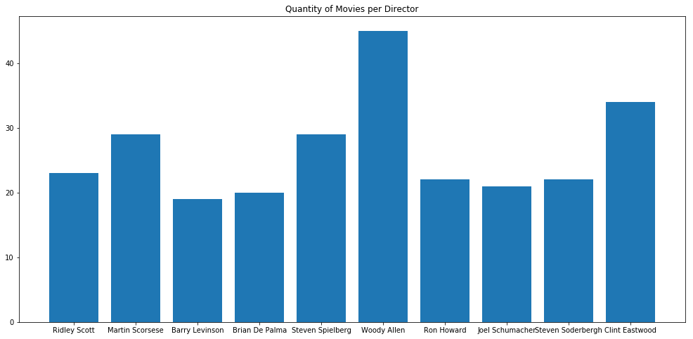

```python
plt.title('Quantity of Movies per Director')
plt.bar(directors_dict.keys(), directors_dict.values())
```

> We now have our list of the top ten most hired directors from this aggregation of movies and a bar graph of how the compare to each other!

> I think I'm going to keep these names in a list, in case I feel like referring to them later.

```python
# I will keep these directors as a list, possibly for use later

top_directors = directors_dict.keys()
```

```python
top_directors
```

```
['Ridley Scott',
 'Martin Scorsese',
 'Barry Levinson',
 'Brian De Palma',
 'Steven Spielberg',
 'Woody Allen',
 'Ron Howard',
 'Joel Schumacher',
 'Steven Soderbergh',
 'Clint Eastwood']
```

### Research Question 2: What is the correlation between a higher budget and a higher revenue?

```python
#I will use the adjusted budget and revenue columns, so all data is in equal terms

unique_imdb_df['budget_adj']
```

```
0        1.379999e+08
1        1.379999e+08
2        1.012000e+08
3        1.839999e+08
4        1.747999e+08
5        1.241999e+08
6        1.425999e+08
7        9.935996e+07
8        6.807997e+07
9        1.609999e+08
10       2.253999e+08
11       1.619199e+08
12       1.379999e+07
13       8.095996e+07
14       2.575999e+08
```

[output cut: 47 more lines]

> So we have our adjusted budget field here, now let's describe our data and look at a plot for comparison. Keep in mind that the description values and the Y axis of the plot will appear in scientific notation, because that is how the data was stored.

```python
# Let's describe the list of budgets here, for fun

unique_imdb_df['budget_adj'].describe()
```

```
count    1.086500e+04
mean     1.754989e+07
std      3.430753e+07
min      0.000000e+00
25%      0.000000e+00
50%      0.000000e+00
75%      2.085325e+07
max      4.250000e+08
Name: budget_adj, dtype: float64
```

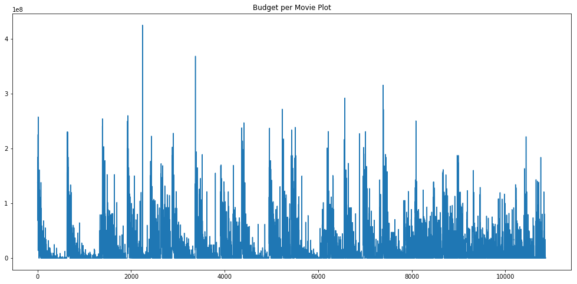

```python
unique_imdb_df.budget_adj.plot(title="Budget per Movie Plot")
```

```python
unique_imdb_df['budget_adj'].idxmax()
```

```
2244
```

```python
# So, it was row 2244. Let's see what movie that is

unique_imdb_df.iloc[2243] #subtracting one because the row returned was not zero-based but indexing is
```

```
id                                                                  46528
imdb_id                                                         tt1032751
popularity                                                        0.25054
budget                                                          425000000
revenue                                                          11087569
original_title                                          The Warrior's Way
cast                    Kate Bosworth|Jang Dong-gun|Geoffrey Rush|Dann...
homepage                           http://www.iamrogue.com/thewarriorsway
director                                                       Sngmoo Lee
tagline                                           Assassin. Hero. Legend.
keywords                assassin|small town|revenge|deception|super speed
overview                An Asian assassin (Dong-gun Jang) is forced to...
runtime                                                               100
genres                          Adventure|Fantasy|Action|Western|Thriller
production_companies                             Boram Entertainment Inc.
release_date                                                    12/2/2010
vote_count                                                             74
vote_average                                                          6.4
release_year                                                         2010
budget_adj                                                       4.25e+08
revenue_adj                                                   1.10876e+07
Name: 2244, dtype: object
```

> It appears that the most costly movie on file was "The Warrior's Way"...I wasn't expecting that!

> Now, let's look over to our revenue field.

```python
unique_imdb_df['revenue_adj']
```

```
0        1.392446e+09
1        3.481613e+08
2        2.716190e+08
3        1.902723e+09
4        1.385749e+09
5        4.903142e+08
6        4.053551e+08
7        5.477497e+08
8        1.064192e+09
9        7.854116e+08
10       8.102203e+08
11       1.692686e+08
12       3.391985e+07
13       2.241460e+08
14       1.292632e+09
```

[output cut: 47 more lines]

> We have our Series here, let's look at the description and plot it like we did for budget. Remember that the Y axis of the plot is in scientific notation!

```python
# Let's describe our revenue field similarly

unique_imdb_df['revenue_adj'].describe()
```

```
count    1.086500e+04
mean     5.136900e+07
std      1.446383e+08
min      0.000000e+00
25%      0.000000e+00
50%      0.000000e+00
75%      3.370173e+07
max      2.827124e+09
Name: revenue_adj, dtype: float64
```

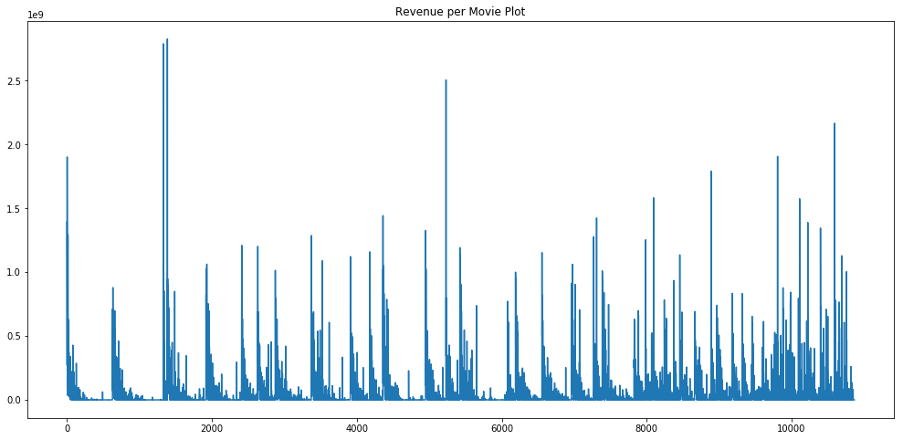

```python
unique_imdb_df.revenue_adj.plot(title='Revenue per Movie Plot')
```

> Let's take a look here too and see which movie made the most money.

```python
unique_imdb_df['revenue_adj'].idxmax()
```

```
1386
```

```python
unique_imdb_df.iloc[1386]
```

```
id                                                                  19995
imdb_id                                                         tt0499549
popularity                                                        9.43277
budget                                                          237000000
revenue                                                        2781505847
original_title                                                     Avatar
cast                    Sam Worthington|Zoe Saldana|Sigourney Weaver|S...
homepage                                      http://www.avatarmovie.com/
director                                                    James Cameron
tagline                                       Enter the World of Pandora.
keywords                culture clash|future|space war|space colony|so...
overview                In the 22nd century, a paraplegic Marine is di...
runtime                                                               162
genres                           Action|Adventure|Fantasy|Science Fiction
production_companies    Ingenious Film Partners|Twentieth Century Fox ...
release_date                                                   12/10/2009
vote_count                                                           8458
vote_average                                                          7.1
release_year                                                         2009
budget_adj                                                    2.40887e+08
revenue_adj                                                   2.82712e+09
Name: 1386, dtype: object
```

> Avatar...No real surprise there!

> So, we can successfully pull values from our adjust budget and revenue columns. Now, let's use pandas' corr() function to see the correlation coefficient between them.

```python
# now let's look  at the correlation between these two

imdb_df['budget_adj'].corr(imdb_df['revenue_adj'])
```

```
0.6466074410661402
```

> So we have here our correlation coefficient. An experienced statistician can probably visualize exactly what this correlation would look like, but for the rest of us I think I'd like to actually plot it.

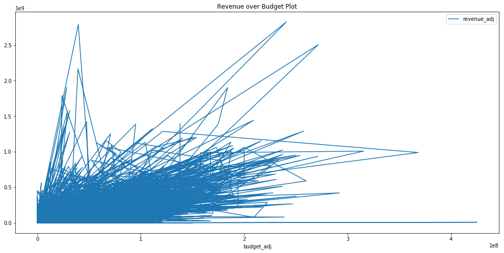

```python
unique_imdb_df.plot(x='budget_adj', y='revenue_adj', title='Revenue over Budget Plot')
```

> Hmmm, that seems a bit messy huh? Let's go ahead and change this to a scatter plot.

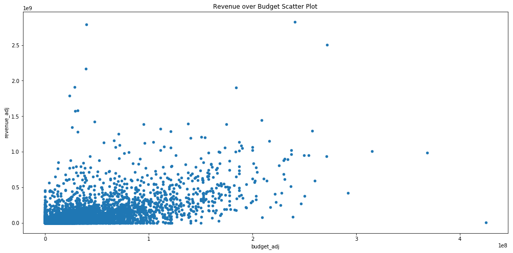

```python
unique_imdb_df.plot(kind='scatter', x='budget_adj', y='revenue_adj', title='Revenue over Budget Scatter Plot')
```

> For fun, see if you can find on our scatterplot here the points for "The Warrior's Way" and "Avatar". They're pretty distinct!

> The Pearson (standard) correlation coefficent of money spent in budget to money received in revenue is only 0.64660744. That's a pretty loose correlation, and the plot feels a bit scattered. Let's see if revenue has a tighter correlation with any other numerical columns.

```python
imdb_df.corr()
```

|  | id | popularity | budget | revenue | runtime | vote_count | vote_average | release_year | budget_adj | revenue_adj |
| --- | --- | --- | --- | --- | --- | --- | --- | --- | --- | --- |
| id | 1.000000 | -0.014350 | -0.141351 | -0.099227 | -0.088360 | -0.035551 | -0.058363 | 0.511364 | -0.189015 | -0.138477 |
| popularity | -0.014350 | 1.000000 | 0.545472 | 0.663358 | 0.139033 | 0.800828 | 0.209511 | 0.089801 | 0.513550 | 0.609083 |
| budget | -0.141351 | 0.545472 | 1.000000 | 0.734901 | 0.191283 | 0.632702 | 0.081014 | 0.115931 | 0.968963 | 0.622505 |
| revenue | -0.099227 | 0.663358 | 0.734901 | 1.000000 | 0.162838 | 0.791175 | 0.172564 | 0.057048 | 0.706427 | 0.919110 |
| runtime | -0.088360 | 0.139033 | 0.191283 | 0.162838 | 1.000000 | 0.163278 | 0.156835 | -0.117204 | 0.221114 | 0.175676 |
| vote_count | -0.035551 | 0.800828 | 0.632702 | 0.791175 | 0.163278 | 1.000000 | 0.253823 | 0.107948 | 0.587051 | 0.707942 |
| vote_average | -0.058363 | 0.209511 | 0.081014 | 0.172564 | 0.156835 | 0.253823 | 1.000000 | -0.117632 | 0.093039 | 0.193085 |
| release_year | 0.511364 | 0.089801 | 0.115931 | 0.057048 | -0.117204 | 0.107948 | -0.117632 | 1.000000 | 0.016793 | -0.066256 |
| budget_adj | -0.189015 | 0.513550 | 0.968963 | 0.706427 | 0.221114 | 0.587051 | 0.093039 | 0.016793 | 1.000000 | 0.646607 |
| revenue_adj | -0.138477 | 0.609083 | 0.622505 | 0.919110 | 0.175676 | 0.707942 | 0.193085 | -0.066256 | 0.646607 | 1.000000 |

> However, I would sort of like to see if the revenue ties back in any way to our previous question, the most popular directors. So let's take a look!

```python
revenue_mean = imdb_df['revenue_adj'].mean()
print revenue_mean
```

```
51364363.2532
```

> With this command, I pulled the mean from the adjusted revenue column.

```python
above_counter = 0
below_counter = 0
for value in imdb_df[imdb_df.director.isin(top_directors)]['revenue_adj']:
    if value > revenue_mean:
        above_counter += 1
    else:
        below_counter += 1
print above_counter
print below_counter

# Thank you to cmdlinetips.com for helping me create that expression!
```

```
147
117
```

> This was an extremely informal way to observe correlation. Because one value was a string and one value was numeric, pandas' correlation coefficient function will not work.

> However, we can see just from these rudimentary outputs that there is not a very high positive correlation between the most popular directors and the highest grossing films, it seems to be a 60/40 split of values even landing on the high side of the mean. I guess quality doesn't always correlate with quantity!

## Conclusions

> Well, with our first question we saw which directors were the most popular in terms of number of movies. Keep in mind, this set of data has over ten thousand records or movies, but I don't think it's an exhaustive list of all movies ever. So the directors that have put out the highest number of movies in this aggreggation aren't necessarily the most active directors of all time.

> Secondly, we saw the correlation in this set between how much was spent on the production of a movie (scaled to 2010 inflation) and how much revenue was gather from it (also scaled to 2010 inflation), and how it wasn't very highly correlated. It is indeed a positive correlation, which was expected, but there was also a lot of variance in the plot. We also saw, on a tangent, that there isn't a very high correlation between our list of directors and the highest grossing movies.

> **Limitations:** As you saw during our data wrangling phase, many of our fields have a number of null values. This could make exploring other, more complex questions a bit difficult, and even if we circumvent that issue there is a chance that it will cause a gap in our results. On top of this issue, there is the face that we do not know exactly how far this list of movies reaches. We could examine the smallest date in the dataframe and assume that the records begin there and go chronologically, but determining whether any movie after that date was missed or omitted would require a lot of cross-checking. Over all, I am quite happy with our results here.